# In this notebook we follow the 10 most popular words in time .

First we need to import all the needed libraries for this project  
We our going to use:

- matplotlib
- pandas
- wordcloud
- regex
- unicodedata

```python
# coding: utf-8
from matplotlib import pyplot as plt
import pandas as pd
import collections
from collections import Counter,defaultdict,OrderedDict,namedtuple
from wordcloud import WordCloud, STOPWORDS, ImageColorGenerator
from datetime import datetime
import re
import unicodedata
import sys
sys.path.insert(1, '/Users/elenikaranikola/Desktop/NewsCleanser')
from settings import wordpopularity_colors
```

- **find_top(x):** gets as input string all articles and returns the 10 most common used words.
- **common_year(x):** gets as imput a year and returns all articles combines in one list of words and the number of articles published the given year.
- **plot_subplots(x):** gets as input a list of all the tuples produced and for each tuple in the list plots its barchart as a group of suplots figure.
- **empty_year_dict():** gets no input and returns a dictionary with keys values from 2013 to 2020 kai values zero. </font>

```python
#read the data
df = pd.read_csv('output.csv')

#fill all null values in the table
df = df.fillna(" ")

#get the article body
articles = list(df['article_body'])

#function to find the 10 most common words
def find_top(articles):
    #initiate an empty list to save all the words of all the articles
    all_words_compined = []

    for words in articles:
        #split the articles to words
        word_list = words.split()
        #save the words to our list
        all_words_compined.extend(word_list)

    #find the 500 most common
    top = Counter(all_words_compined).most_common(10)
    return top



#give the year of interest and return the 100 most popular words of the whole data
# min year is 2013 max year is 2020
def common_year(year):
    text0 = " "
    counter = 0
    for row_index,row in df.iterrows():
        date = row['article_date']
        text = row['article_body']
        if re.search(r'\d\d\d\d',date).group(0) == year:
            counter += 1
            text0 = text0 + text

    text_to_words = text0.split()

    #top = Counter(text_to_words).most_common(100)
    return (text_to_words,counter)




#function to create a dictionary with keys the year 2013 to 2020 and values zero
def empty_year_dict():
    #create a list with the years from 2013 to 2020
    years = []
    for k in range(2013, 2021):
        years.append(k)

    #create dict with years as key and 0 for value
    year_dict = {k:(0,0) for k in years}
    return(year_dict)



#loop over each word, create an new dict with the years for key and zero value
#rotate over each years articles and count the times the words appears
#plot a bar chart for each word

def print_barcharts(top):
    #this list will containes all the tuples
    list_with_tuple = []

    for i in top:
        #get empty dictionary with the years as keys
        year_dict = empty_year_dict()

        #rotate over the keys and count
        for year in year_dict:

            res = common_year(str(year))
            text = res[0]
            counter = res[1]

            #devide the number of time the words appeared with the number of each years articles
            temp = (text.count(i[0])/counter)

            year_dict.update({year:temp})
            #neg_dict.update({y:neg_dict[y]+1})

        list_with_tuple.append((year_dict,i[0]))

    #tuple contais spot [0]:the years with the count of each words and in spot[1]:the words itself
    plot_subplots(list_with_tuple)


def plot_subplots(list_with_tuple):
        #define suplots figure layout and size
        fig, axs = plt.subplots(5,2,figsize=(15,35))
        index = 0
        counter = 0
        for i in list_with_tuple:

            year_dict = i[0]
            word = i[1]
            year = []
            count = []
            for key in year_dict:
                year.append(key)
                count.append(year_dict[key])

            if counter == 0:
                #set a color from the wordpopularity_colors list imported from settings
                my_color = wordpopularity_colors.pop(0)
                axs[index,counter].bar(year, count, color = my_color)
                axs[index,counter].set_title('Bar chart for the word "'+word+'" from 2013-2020')
                axs[index,counter].grid(axis='y')
                #axs[index,counter].show()
                counter = 1
            else:
                #set a color from the wordpopularity_colors list imported from settings
                my_color = wordpopularity_colors.pop(0)
                axs[index,counter].bar(year, count, color = my_color)
                axs[index,counter].set_title('Bar chart for the word "'+word+'" from 2013-2020')
                axs[index,counter].grid(axis='y')
                #axs[index,counter].show()
                counter = 0
                index += 1
        plt.show()
```

The idea is that after counting the times a word appears in each year's articles we will devide it by the total publications that happend that year to get a better understanding of the actual popularity of the word.

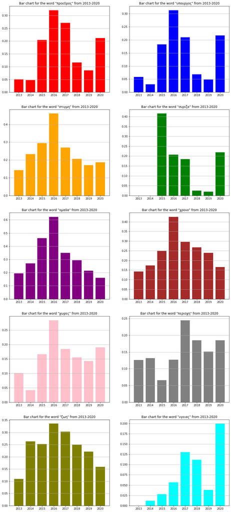

```python
#get the top 10 most popular words
top = find_top(articles)

#plot the barcharts
print_barcharts(top)
```